# Machine Learning Project

Author: Hannah Hon

### Background

Using devices such as Jawbone Up, Nike FuelBand, and Fitbit it is now possible to collect a large amount of data about personal activity relatively inexpensively. These type of devices are part of the quantified self movement – a group of enthusiasts who take measurements about themselves regularly to improve their health, to find patterns in their behavior, or because they are tech geeks. One thing that people regularly do is quantify how much of a particular activity they do, but they rarely quantify how well they do it. In this project, the goal will be to use data from accelerometers on the belt, forearm, arm, and dumbell of 6 participants. They were asked to perform barbell lifts correctly and incorrectly in 5 different ways.

### Library

```r
library(caret)
library(rpart)
library(rattle)
```

### Getting and Cleaning Data

```r
train <- "https://d396qusza40orc.cloudfront.net/predmachlearn/pml-training.csv"
test <- "https://d396qusza40orc.cloudfront.net/predmachlearn/pml-testing.csv"
train <- download.file(train,"./data")
training <- read.csv("train")
test <- download.file(test, "./test")
testing <- read.csv("test")
## remove the invalid columes
training <- training[,colSums(is.na(training)) == 0]
testing <- testing[,colSums(is.na(testing)) == 0]
dim(training)
```

```
## [1] 19622    93
```

```r
dim(testing)
```

```
## [1] 20 60
```

```r
## Now remove the first 7 outputs as they have few impact on Classe
training <- training[,-c(1:7)]
testing <- testing[,-c(1:7)]
dim(training)
```

```
## [1] 19622    86
```

```r
dim(testing)
```

```
## [1] 20 53
```

### Preparation for Prediction

```r
inTrain <- createDataPartition(training$classe, p = 0.7, list = FALSE)
trainData <- training[inTrain, ]
testData <- training[-inTrain,]
NZV <- nearZeroVar(trainData)
trainData <- trainData[, -NZV]
testData  <- testData[, -NZV]
dim(trainData)
```

```
## [1] 13737    53
```

### Prediction Model Building

```r
set.seed(12345)
controlrf <- trainControl(method="cv", number=3, verboseIter=FALSE)
rf <- train(classe ~ ., trainData, method="rf",trControl=controlrf)
rf$finalModel
```

```
##
## Call:
##  randomForest(x = x, y = y, mtry = param$mtry)
##                Type of random forest: classification
##                      Number of trees: 500
## No. of variables tried at each split: 27
##
##         OOB estimate of  error rate: 0.7%
## Confusion matrix:
##      A    B    C    D    E class.error
## A 3901    3    1    0    1 0.001280082
## B   17 2631   10    0    0 0.010158014
## C    0    8 2379    9    0 0.007095159
## D    0    2   28 2218    4 0.015097691
## E    0    1    5    7 2512 0.005148515
```

```r
modelrf <- predict(rf, testData)
conf <- confusionMatrix(modelrf,testData$classe)
conf
```

```
## Confusion Matrix and Statistics
##
##           Reference
## Prediction    A    B    C    D    E
##          A 1673    4    0    0    0
##          B    0 1132   12    1    0
##          C    1    3 1008    7    1
##          D    0    0    6  956    2
##          E    0    0    0    0 1079
##
## Overall Statistics
##
##                Accuracy : 0.9937
##                  95% CI : (0.9913, 0.9956)
##     No Information Rate : 0.2845
##     P-Value [Acc > NIR] : < 2.2e-16
##
##                   Kappa : 0.992
##  Mcnemar's Test P-Value : NA
##
## Statistics by Class:
##
##                      Class: A Class: B Class: C Class: D Class: E
## Sensitivity            0.9994   0.9939   0.9825   0.9917   0.9972
## Specificity            0.9991   0.9973   0.9975   0.9984   1.0000
## Pos Pred Value         0.9976   0.9886   0.9882   0.9917   1.0000
## Neg Pred Value         0.9998   0.9985   0.9963   0.9984   0.9994
## Prevalence             0.2845   0.1935   0.1743   0.1638   0.1839
## Detection Rate         0.2843   0.1924   0.1713   0.1624   0.1833
## Detection Prevalence   0.2850   0.1946   0.1733   0.1638   0.1833
## Balanced Accuracy      0.9992   0.9956   0.9900   0.9950   0.9986
```

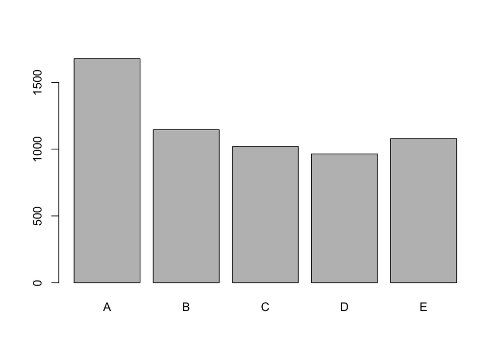

```r
plot(modelrf)
```

#### 2. Decision Tree

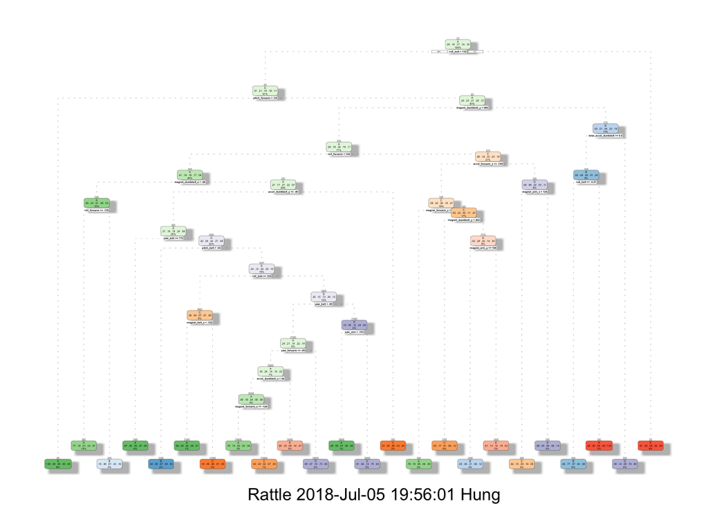

```r
modelrp <- rpart(classe ~ ., trainData, method="class")
fancyRpartPlot(modelrp)
```

```r
trainpred <- predict(modelrp, testData, type = "class")
confrp <- confusionMatrix(testData$classe,trainpred)
```

#### 3. Generalized Boosted

```r
set.seed(12345)
controlgbm <- trainControl(method = "repeatedcv", number = 5, repeats = 1)
modelgbm  <- train(classe ~ ., data=trainData, method = "gbm",
                    trControl = controlgbm, verbose = FALSE)
modelgbm$finalModel
```

```
## A gradient boosted model with multinomial loss function.
## 150 iterations were performed.
## There were 52 predictors of which 43 had non-zero influence.
```

```r
predictgbm <- predict(modelgbm, newdata=testData)
confgbm <- confusionMatrix(predictgbm, testData$classe)
confgbm
```

```
## Confusion Matrix and Statistics
##
##           Reference
## Prediction    A    B    C    D    E
##          A 1650   25    0    0    1
##          B   15 1085   44    5   14
##          C    8   27  972   36    9
##          D    1    1    8  908   17
##          E    0    1    2   15 1041
##
## Overall Statistics
##
##                Accuracy : 0.9611
##                  95% CI : (0.9558, 0.9659)
##     No Information Rate : 0.2845
##     P-Value [Acc > NIR] : < 2.2e-16
##
##                   Kappa : 0.9508
##  Mcnemar's Test P-Value : 7.766e-08
##
## Statistics by Class:
##
##                      Class: A Class: B Class: C Class: D Class: E
## Sensitivity            0.9857   0.9526   0.9474   0.9419   0.9621
## Specificity            0.9938   0.9836   0.9835   0.9945   0.9963
## Pos Pred Value         0.9845   0.9329   0.9240   0.9711   0.9830
## Neg Pred Value         0.9943   0.9886   0.9888   0.9887   0.9915
## Prevalence             0.2845   0.1935   0.1743   0.1638   0.1839
## Detection Rate         0.2804   0.1844   0.1652   0.1543   0.1769
## Detection Prevalence   0.2848   0.1976   0.1788   0.1589   0.1799
## Balanced Accuracy      0.9897   0.9681   0.9655   0.9682   0.9792
```

### Applying selected model to testing data

```r
predictTest <- predict(rf,testing)
predictTest
```

```
##  [1] B A B A A E D B A A B C B A E E A B B B
## Levels: A B C D E
```